# Kernel methods

## 지지도벡터분류자 Support Vector Classifier

### 선형 분리 가능한 초평면 linearly separable hyperplane

- 2개의 설명변수($X_1$, $X_2$) 공간 상에서 두개의 클래스를 분류하는 문제를 가정
- 두 클래스가 선형식을 기준으로 분리가 가능한 경우, 모든 관측점들에 대해 두 그룹으로 완벽히 나눌수 있는 경계선을 그릴 수 있음

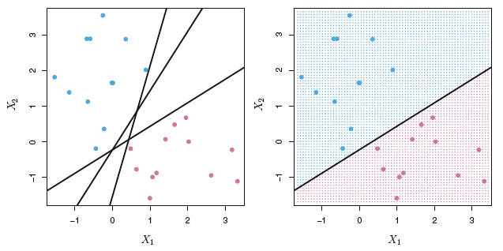

- 가장 직관적인 (그리고 유일한 해법을 주는) 접근 방법은 가장 명확하게 그룹을 나누는 경계직선을 선택하는 것임. 예를 들어 경계직선으로부터 그룹별 관측점들과 최대한 거리가 먼 직선을 선택

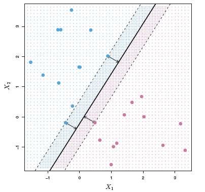

- 이를 구현한 것이 **지지도벡터분류자**(support vector classifier) 기법임
  - 그림에서 $M$은 분리선과 각 클래스의 점들 사이의 최소 수직 거리
  - $M$을 최대로 하는 경계직선을 찾는 것이 목표
  - 이 경계직선을 **최적분리초평면** (optimal separating hyperplane) 라 부름
  - 모든 점들은 최적분리초평면을 사이에 둔 **경계**(margin)의 안쪽에 놓이게 됨
  - 특정 점에 대한 분류(클래스 예측)는 이 경계를 기준으로 어디에 놓이느냐에 의해 결정

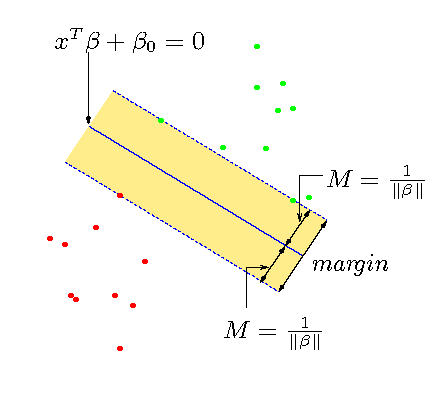

- 설명변수가 아주 많이 있는 경우로 확장 가능
  - 클래스별 최대분리거리를 계산하여 분리 기준이 되는 평면을 찾을 수 있음
  - 3차원 이상일 경우 시각화의 어려움이 있으나 분류를 위한 평면은 존재. 눈으로 볼 수 없는 이러한 평면을 **초평면** (hyperplanes) 이라 부름

### 분리 불가능인 경우 Non-separable case

- 두 그룹을 완벽하게 분리하는 초평면을 찾는 것이 불가능한 경우임
- 어떠한 직선 혹은 평면을 사용하더라도 항상 일부는 잘못 분류됨
- **전략** : 허용한계를 설정하고 이 허용한계 내에서 정분류되는 두 그룹 사이의 거리가 최대가 되도록 분리해주는 초평면을 찾음
- Slack variable
  - $\xi^{\ast}_{i}$는 $i$번째 자료점이 잘못 분류된 정도를 경계(margin)로부터의 거리로 측정한 값
  - 자료점이 경계의 안쪽에 놓여 정분류된 경우에는 $\xi_i^*=0$
  - $\xi_i^*$를 **완화변수**(**slack variable**)라 부름
  - $M$을 최대화하되 다음의 제약 조건 하에서 수행:
    $$\sum^{n}_{i=1} \xi^{\ast}_{i} \le C$$
  - 위의 $C$는 조절모수(tuning parameter)로써 분류성능이 최대가 되도록 선택해야 함

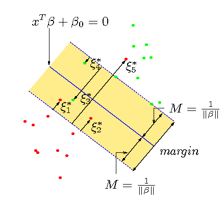

- 모의실험 예시 – $C$값이 작을 때
  - 점선과 점선 사이의 거리는 경계(margin)간의 거리이며 $2\times M$로 주어짐
  - 보라색 선은 베이즈결정경계(Bayes decision boundaries)임

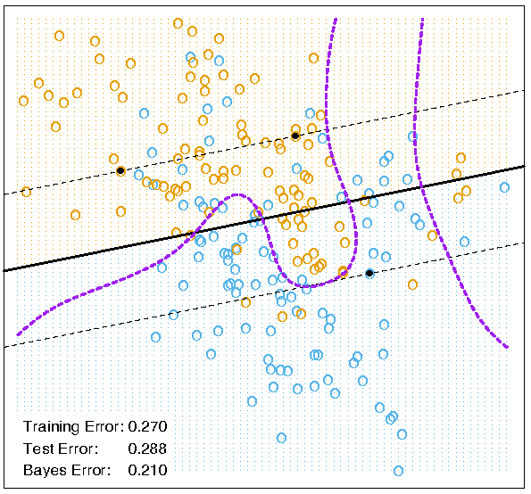

- 모의실험 예시 – $C$값이 클 때
  - 큰 상수를 쓴다는 것은 더 큰 경계폭을 허용한다는 의미, 즉 다수의 점들이 경계 밖에 놓이는 것을 허용

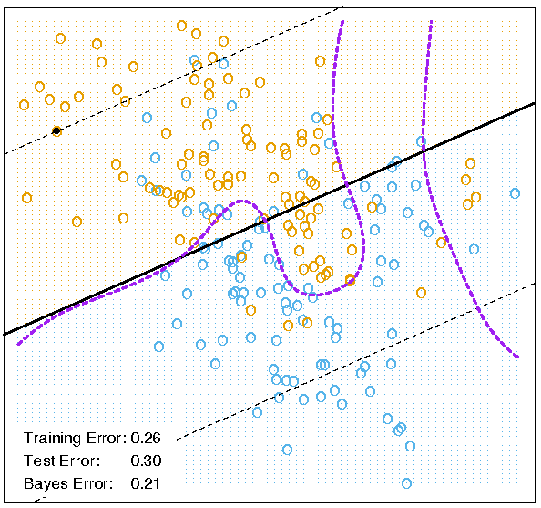

## 지지도벡터기계 Support Vector Machines

### 비선형 분류자 Non-linear classifier

- 지지도벡터분류자는 이해하기 쉽지고 직관적이지만, **결정경계가 선형**으로 주어지는 한계가 있음
- 기저함수(basis function)를 사용하여 선형모형 기법으로 비선형모형을 구축하는 것이 가능

$$Y_i = \beta_0 + \beta_1 \varphi_1 (X_i) + \beta_2 \varphi_2 (X_i) + \cdots + \beta_p \varphi_m (X_i) + \epsilon_i$$

### 기저함수 접근법

- 지지도벡터분류자(support vector classifier)는 $X_1, X_2, \dots, X_p$의 공간에서 최적의 초평면(선형)을 찾음
- 대신, **변환공간 $\varphi_1 (X), \varphi_2 (X), \ldots , \varphi_m (X)$ 상에서 최적의 초평면을 찾음**
  - 변환공간의 차원 $m$은 일반적으로 설명변수공간의 차원 $p$보다 큼. 무한차원의 변환공간 ($m=\infty$)이 필요한 경우도 있음
- 이는 변환공간상에서 분류을 위한 선형 초평면을 생성하지만, 이를 원래의 **설명변수공간으로 역변환하면 비선형 초평면을 얻게됨** $\Rightarrow$ 매우 유연한(flexible) 분류 규칙을 제공함

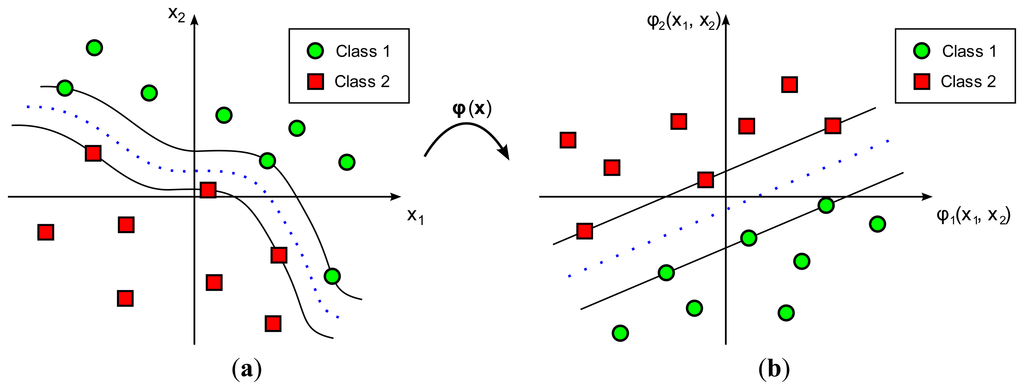

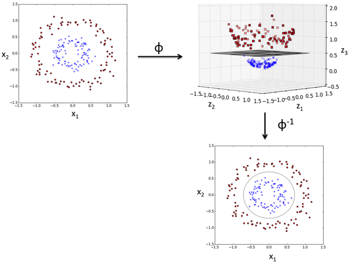

### 커널함수의 이용

- **어떤 기저함수를 사용하는가**가 지지도벡터기계의 성능을 결정
  - 기저함수의 종류는 무한함
  - 변환–역변환 과정에서 계산상 어려움이 존재
  - 이는 구현시 어려움을 야기함
- 일반적으로 지지도벡터기계 기법 활용시, 기저함수를 선택하는 대신 **커널함수**(kernel function)를 선택
  - 커널함수와 기저함수 간의 대응관계를 이용
  - 복잡한 기저함수의 적용 및 변환의 필요없이 간단히 **커널함수의 선택 및 내적(inner product) 계산** 만을 통해 classifier 함수 구현 가능
    $$f(x) = \beta_0 + \sum_{i\in S} \alpha_i K(x, x_i)$$
  - 이를 **커널트릭**(**kernel trick**)이라 함
- 많이 사용되는 커널함수의 예
  - Linear
    $$K(x,x') = \langle x, x'\rangle$$
  - Polynomial
    $$K(x,x') = (1+\langle x, x'\rangle)^d$$
  - Sigmoid
    $$K(x,x') = \tanh(\kappa_1\langle x,x'\rangle +\kappa_2)$$
  - Radial Basis
    $$K(x,x') = \exp(-\gamma\|x-x'\|^2)$$
- **polynomial kernel** 사용 예

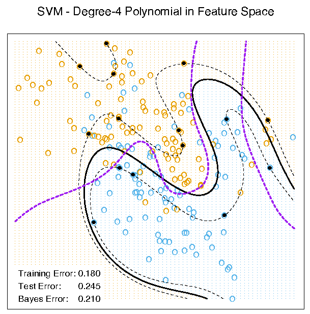

- **radial basis kernel** 사용 예

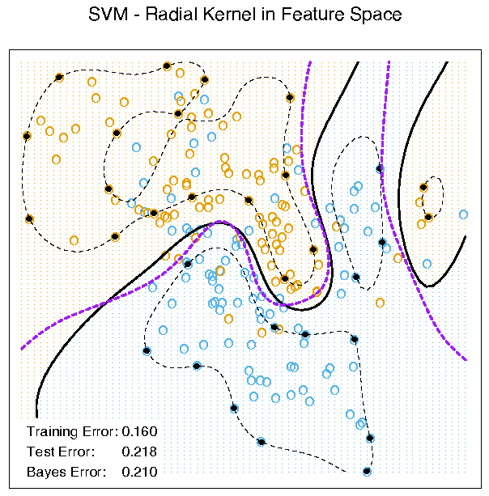

### Example: `Glass` 데이터

- `e1071` 패키지 및 예제 데이터 로드

```r
library(e1071)

data(Glass, package = "mlbench")
str(Glass)
```

```
## 'data.frame':    214 obs. of  10 variables:
##  $ RI  : num  1.52 1.52 1.52 1.52 1.52 ...
##  $ Na  : num  13.6 13.9 13.5 13.2 13.3 ...
##  $ Mg  : num  4.49 3.6 3.55 3.69 3.62 3.61 3.6 3.61 3.58 3.6 ...
##  $ Al  : num  1.1 1.36 1.54 1.29 1.24 1.62 1.14 1.05 1.37 1.36 ...
##  $ Si  : num  71.8 72.7 73 72.6 73.1 ...
##  $ K   : num  0.06 0.48 0.39 0.57 0.55 0.64 0.58 0.57 0.56 0.57 ...
##  $ Ca  : num  8.75 7.83 7.78 8.22 8.07 8.07 8.17 8.24 8.3 8.4 ...
##  $ Ba  : num  0 0 0 0 0 0 0 0 0 0 ...
##  $ Fe  : num  0 0 0 0 0 0.26 0 0 0 0.11 ...
##  $ Type: Factor w/ 6 levels "1","2","3","5",..: 1 1 1 1 1 1 1 1 1 1 ...
```

- 데이터 split

```r
train_index <- sample(1:nrow(Glass), round(nrow(Glass)*0.7))
GlassTrain <- Glass[train_index,]
GlassTest <- Glass[-train_index,]
```

- SVM 학습

```r
svm.model <- svm(Type ~ ., data = GlassTrain, cost = 100, gamma = 1)
```

- Test 데이터에 적용해 분류 성능 확인

```r
pred <- predict(svm.model, GlassTest[,-10])
table(pred, GlassTest$Type) # confusion matrix
```

```
##
## pred  1  2  3  5  6  7
##    1 18  7  3  0  0  0
##    2  3 14  2  2  1  4
##    3  0  1  0  0  0  0
##    5  0  0  0  2  0  0
##    6  0  0  0  0  1  0
##    7  0  0  0  0  0  6
```